# house_pred

```python
import pandas as pd
import numpy as np
import seaborn as sns
import matplotlib.pyplot as plt
%matplotlib inline
import warnings
warnings.filterwarnings('ignore')
```

```python
data=pd.read_csv(r'D:\House_price-main\House_price-main\houseprice.csv')
```

our aim is to build a housing price prediction model . As a person who is looking for a home and needs to know in a certain area how much a house cost, will be considering essential things which meets all basic requirements . #roads #basic utilities #nearest to town or not(to ensure proper hospitality , education etc) #vehicle space #family size which includes rooms for each member #furnished or not # bathrooms # a good kitchen

Checking if we can extract these much details from the given data

```python
data.head()
```

|  | Id | MSSubClass | MSZoning | LotFrontage | LotArea | Street | Alley | LotShape | LandContour | Utilities | ... | PoolArea | PoolQC | Fence | MiscFeature | MiscVal | MoSold | YrSold | SaleType | SaleCondition | SalePrice |
| --- | --- | --- | --- | --- | --- | --- | --- | --- | --- | --- | --- | --- | --- | --- | --- | --- | --- | --- | --- | --- | --- |
| 0 | 1 | 60 | RL | 65.0 | 8450 | Pave | NaN | Reg | Lvl | AllPub | ... | 0 | NaN | NaN | NaN | 0 | 2 | 2008 | WD | Normal | 208500 |
| 1 | 2 | 20 | RL | 80.0 | 9600 | Pave | NaN | Reg | Lvl | AllPub | ... | 0 | NaN | NaN | NaN | 0 | 5 | 2007 | WD | Normal | 181500 |
| 2 | 3 | 60 | RL | 68.0 | 11250 | Pave | NaN | IR1 | Lvl | AllPub | ... | 0 | NaN | NaN | NaN | 0 | 9 | 2008 | WD | Normal | 223500 |
| 3 | 4 | 70 | RL | 60.0 | 9550 | Pave | NaN | IR1 | Lvl | AllPub | ... | 0 | NaN | NaN | NaN | 0 | 2 | 2006 | WD | Abnorml | 140000 |
| 4 | 5 | 60 | RL | 84.0 | 14260 | Pave | NaN | IR1 | Lvl | AllPub | ... | 0 | NaN | NaN | NaN | 0 | 12 | 2008 | WD | Normal | 250000 |

5 rows × 81 columns

```python
data.shape
```

```
(1460, 81)
```

All data matters although let us sort the data as per our goal

```python
data.nunique()
```

```
Id               1460
MSSubClass         15
MSZoning            5
LotFrontage       110
LotArea          1073
                 ...
MoSold             12
YrSold              5
SaleType            9
SaleCondition       6
SalePrice         663
Length: 81, dtype: int64
```

```python
mask=data.nunique()==1
```

```python
mask.value_counts()
```

```
False    81
dtype: int64
```

```python
data.isna().sum()
```

```
Id                 0
MSSubClass         0
MSZoning           0
LotFrontage      259
LotArea            0
                ...
MoSold             0
YrSold             0
SaleType           0
SaleCondition      0
SalePrice          0
Length: 81, dtype: int64
```

## data selection

```python
filt=data.isna().sum()/len(data.index)*100>50
data_filt=data.columns[filt]
data_filt
```

```
Index(['Alley', 'PoolQC', 'Fence', 'MiscFeature'], dtype='object')
```

these values have greater than 50% of null values hence dropping

As per the data , we have to find the things which are significant for the prediction

dwelling - a shelter (such as a house) in which people live.

```python
data.MSSubClass.value_counts()
#as per the data values provided in the basis of facilities provided , we could classify it into the needed one . %we can include it as our furnished category
```

```
20     536
60     299
50     144
120     87
30      69
160     63
70      60
80      58
90      52
190     30
85      20
75      16
45      12
180     10
40       4
Name: MSSubClass, dtype: int64
```

```python
data.MSZoning.value_counts() #zoning can play an important role with other features like price , road facility, shops,Type of utilities available etc.
```

```
RL         1151
RM          218
FV           65
RH           16
C (all)      10
Name: MSZoning, dtype: int64
```

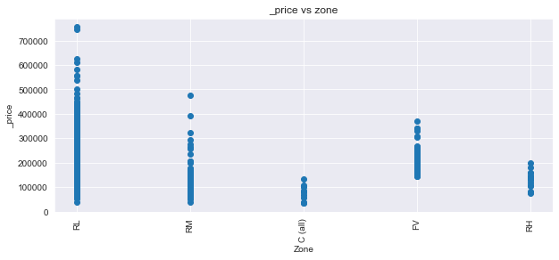

```python
plt.figure(figsize=(10,4))
plt.scatter(x=data.MSZoning,y=data.SalePrice)
plt.xlabel('Zone')
plt.xticks(rotation=90)
plt.title('_price vs zone')
plt.ylabel('_price')
plt.show()
```

The thing is zoning have essential conttribution in sales price. Also a good factor to get customer preferences

```
   A    Agriculture
   C    Commercial
   FV   Floating Village Residential
   I    Industrial
   RH   Residential High Density
   RL   Residential Low Density
   RP   Residential Low Density Park
   RM   Residential Medium Density
```

```python
data.Neighborhood
```

```
0       CollgCr
1       Veenker
2       CollgCr
3       Crawfor
4       NoRidge
         ...
1455    Gilbert
1456     NWAmes
1457    Crawfor
1458      NAmes
1459    Edwards
Name: Neighborhood, Length: 1460, dtype: object
```

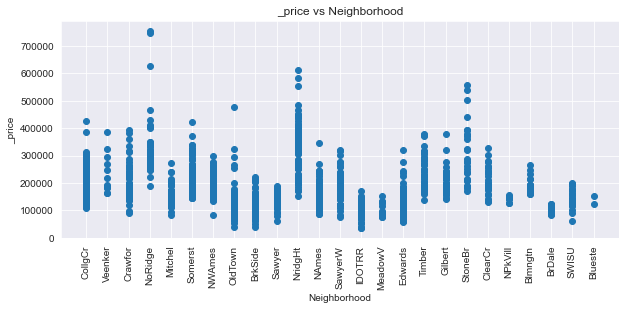

```python
plt.figure(figsize=(10,4))
plt.scatter(x=data.Neighborhood,y=data.SalePrice)
plt.xlabel('Neighborhood')
plt.xticks(rotation=90)
plt.title('_price vs Neighborhood')
plt.ylabel('_price')
plt.show()
```

neighbourhood towns have importance in predicting the sales price . Town can offer better facilities hence increase in rate

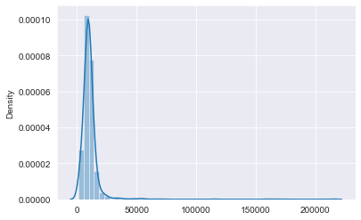

```python
sns.distplot(x=data.LotArea)
```

road to the Area can linearly depend the price of the house as per market .

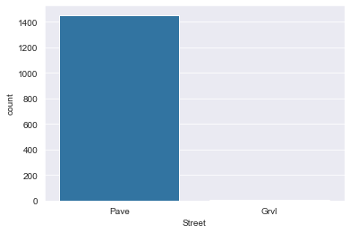

```python
sns.countplot(data.Street)
```

data of road is imbalanced , it would not give any positive impact on the prediction. So here we are dropping the feature

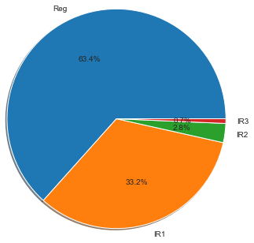

```python
plt.pie(data.LotShape.value_counts().values[0:10],labels=data.LotShape.value_counts().index[0:10],autopct='%1.1f%%', shadow=True, radius=1.6)
plt.show()
```

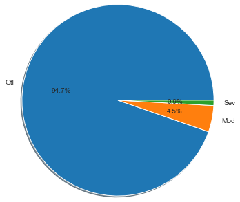

```python
plt.pie(data.LandSlope.value_counts().values[0:10],labels=data.LandSlope.value_counts().index[0:10],autopct='%1.1f%%', shadow=True, radius=1.6)
plt.show()
```

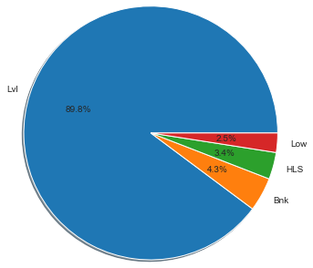

```python
plt.pie(data.LandContour.value_counts().values[0:10],labels=data.LandContour.value_counts().index[0:10],autopct='%1.1f%%', shadow=True, radius=1.6)
plt.show()
```

LotShape , LandSlope ,LandContour are the properites related with shape of the area . I would not wish to consider these factors in our model .

Assuming in general: Lot shape , inlination all are not factors which users prefer while checking the prices

Lot configuration - That depends on vegetation, maintenance and need for space. The location and neighborhood matter and then there are taxes, upkeep. Some people don’t want to do a lot of maintenance. There are 2 sides to most things. So as a seller it matters !! So adding up lot configuration into our aim

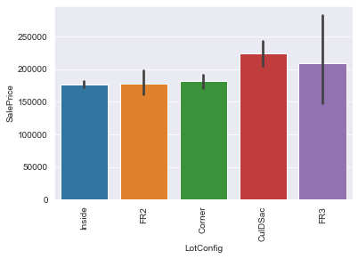

```python
sns.barplot(x=data.LotConfig,y=data.SalePrice)
plt.xticks(rotation=90)
plt.show()
```

CulDSac a street or passage closed at one end.which gets more sales price

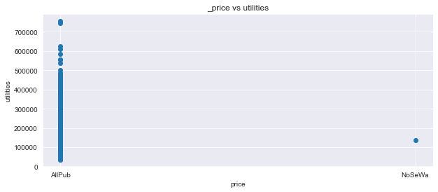

```python
plt.figure(figsize=(10,4))
plt.scatter(x=data.Utilities,y=data.SalePrice)
plt.xlabel('price')
plt.title('_price vs utilities')
plt.ylabel('utilities')
plt.show()
```

```python
data.Utilities.value_counts()
```

```
AllPub    1459
NoSeWa       1
Name: Utilities, dtype: int64
```

# nobody wish to spend on homes without Electricity, Gas, and Water . Hence dropping the factor as well

```python
data.GarageCond.value_counts()
```

```
TA    1326
Fa      35
Gd       9
Po       7
Ex       2
Name: GarageCond, dtype: int64
```

Garage : factors we consider in the case of garage is garage area and condition

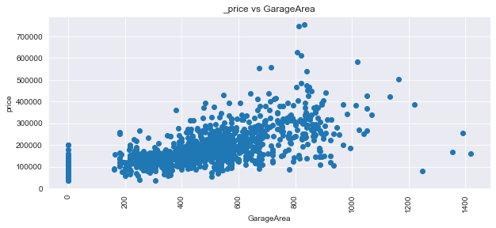

```python
plt.figure(figsize=(10,4))
plt.scatter(x=data.GarageArea,y=data.SalePrice)
plt.xlabel('GarageArea')
plt.xticks(rotation=90)
plt.title('_price vs GarageArea')
plt.ylabel('price')
plt.show()
```

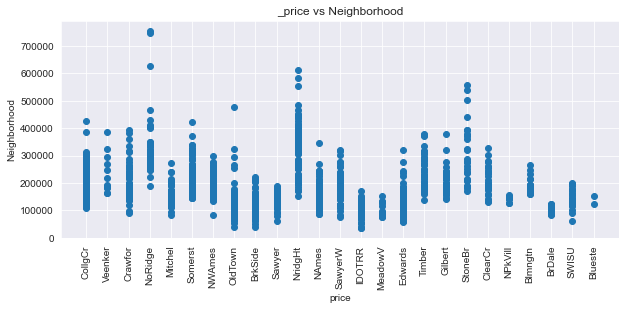

```python
plt.figure(figsize=(10,4))
plt.scatter(x=data.Neighborhood,y=data.SalePrice)
plt.xlabel('price')
plt.xticks(rotation=90)
plt.title('_price vs Neighborhood')
plt.ylabel('Neighborhood')
plt.show()
```

As expected , based on neigbhour towns prices dramatically varies

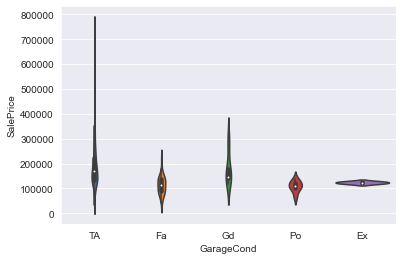

```python
sns.violinplot(x=data.GarageCond,y=data.SalePrice)
```

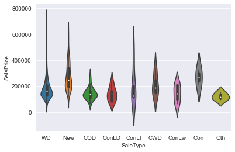

```python
sns.violinplot(x=data.SaleType,y=data.SalePrice)
```

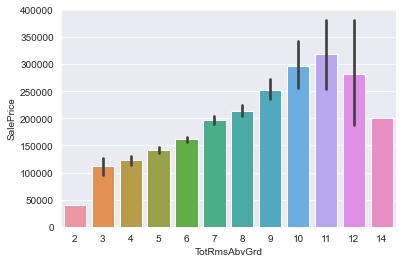

```python
sns.barplot(x=data.TotRmsAbvGrd,y=data.SalePrice)
```

In real estate, above grade means the portion of a home that is above the ground. The term is usually used to describe a room or square footage. For example, 3 bedrooms above grade means 3 bedrooms that are not in a basement. The term above grade is used to give more information about where things are located in a home. Many homes in Edmonton have basements, and many of those basements are very usable, desirable areas, but the fact of the matter is they are still basements, and basement areas are not as desirable as above ground areas.

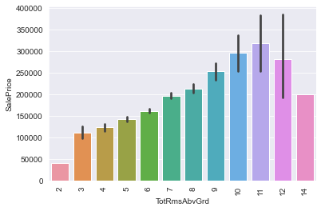

```python
sns.barplot(x=data.TotRmsAbvGrd,y=data.SalePrice)
plt.xticks(rotation=90)
plt.show()
```

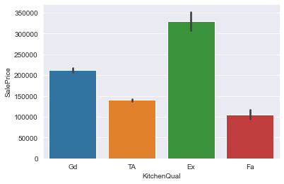

```python
sns.barplot(x=data.KitchenQual,y=data.SalePrice)
```

People usually prefers homes with better kitchen facilities

```python
data.YrSold.value_counts()
```

```
2009    338
2007    329
2006    314
2008    304
2010    175
Name: YrSold, dtype: int64
```

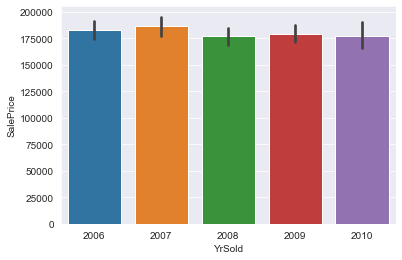

```python
sns.barplot(data.YrSold,data.SalePrice)
```

```python
data.columns
```

```
Index(['Id', 'MSSubClass', 'MSZoning', 'LotFrontage', 'LotArea', 'Street',
       'Alley', 'LotShape', 'LandContour', 'Utilities', 'LotConfig',
       'LandSlope', 'Neighborhood', 'Condition1', 'Condition2', 'BldgType',
       'HouseStyle', 'OverallQual', 'OverallCond', 'YearBuilt', 'YearRemodAdd',
       'RoofStyle', 'RoofMatl', 'Exterior1st', 'Exterior2nd', 'MasVnrType',
       'MasVnrArea', 'ExterQual', 'ExterCond', 'Foundation', 'BsmtQual',
       'BsmtCond', 'BsmtExposure', 'BsmtFinType1', 'BsmtFinSF1',
       'BsmtFinType2', 'BsmtFinSF2', 'BsmtUnfSF', 'TotalBsmtSF', 'Heating',
       'HeatingQC', 'CentralAir', 'Electrical', '1stFlrSF', '2ndFlrSF',
       'LowQualFinSF', 'GrLivArea', 'BsmtFullBath', 'BsmtHalfBath', 'FullBath',
       'HalfBath', 'BedroomAbvGr', 'KitchenAbvGr', 'KitchenQual',
       'TotRmsAbvGrd', 'Functional', 'Fireplaces', 'FireplaceQu', 'GarageType',
       'GarageYrBlt', 'GarageFinish', 'GarageCars', 'GarageArea', 'GarageQual',
       'GarageCond', 'PavedDrive', 'WoodDeckSF', 'OpenPorchSF',
       'EnclosedPorch', '3SsnPorch', 'ScreenPorch', 'PoolArea', 'PoolQC',
       'Fence', 'MiscFeature', 'MiscVal', 'MoSold', 'YrSold', 'SaleType',
       'SaleCondition', 'SalePrice'],
      dtype='object')
```

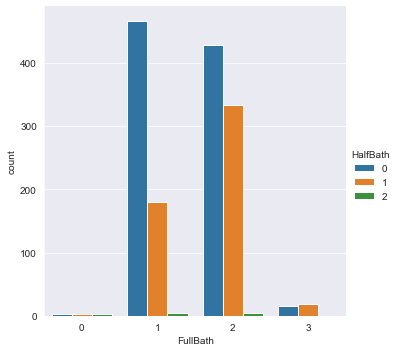

```python
plt.figure(figsize = (14,6))
sns.catplot(x="FullBath", hue="HalfBath",kind="count",data=data)
plt.show()
```

Full bathrooms are higher in count than half bathrooms

These factors are needed enough for us to fulfill our designed model . Hence proceeding with prerocessing the finalized data

```python
final_data=data[['MSSubClass','LotArea','BedroomAbvGr','MSZoning','HalfBath','FullBath','LotConfig','Neighborhood','OverallCond','YearBuilt','YearRemodAdd','Exterior1st','ExterCond','KitchenQual','TotRmsAbvGrd','GarageArea','GarageQual','SaleType','SalePrice']]
```

```python
final_data.isna().sum()
```

```
MSSubClass       0
LotArea          0
BedroomAbvGr     0
MSZoning         0
HalfBath         0
FullBath         0
LotConfig        0
Neighborhood     0
OverallCond      0
YearBuilt        0
YearRemodAdd     0
Exterior1st      0
ExterCond        0
KitchenQual      0
TotRmsAbvGrd     0
GarageArea       0
GarageQual      81
SaleType         0
SalePrice        0
dtype: int64
```

```python
final_data['Built_Year']=final_data['YearBuilt'].max()-final_data['YearBuilt']
```

```python
final_data['Remodelled_year']=final_data['YearRemodAdd'].max()-final_data['YearRemodAdd']
```

```python
final_data=final_data.drop(final_data[['YearBuilt','YearRemodAdd']],axis=1)
```

```python
final_data['GarageQual']=final_data['GarageQual'].fillna(final_data['GarageQual'].mode()[0])
```

```python
data[data.Exterior1st==data.Exterior2nd].shape
```

```
(1245, 81)
```

one feature is considered due to the higher similarities

These factors are considered

```python
final_data.isna().sum()
```

```
MSSubClass         0
LotArea            0
BedroomAbvGr       0
MSZoning           0
HalfBath           0
FullBath           0
LotConfig          0
Neighborhood       0
OverallCond        0
Exterior1st        0
ExterCond          0
KitchenQual        0
TotRmsAbvGrd       0
GarageArea         0
GarageQual         0
SaleType           0
SalePrice          0
Built_Year         0
Remodelled_year    0
dtype: int64
```

```python
obj=final_data.select_dtypes(include=['object'])
```

```python
obj.nunique()
```

```
MSZoning         5
LotConfig        5
Neighborhood    25
Exterior1st     15
ExterCond        5
KitchenQual      4
GarageQual       5
SaleType         9
dtype: int64
```

```python
from sklearn.preprocessing import LabelEncoder,OneHotEncoder

lis=final_data[['Neighborhood','Exterior1st','MSZoning','SaleType','LotConfig','KitchenQual','GarageQual','ExterCond']]
lb=LabelEncoder()
for i in lis:
    final_data[i]=lb.fit_transform(final_data[i])
```

```python
obj
```

|  | MSZoning | LotConfig | Neighborhood | Exterior1st | ExterCond | KitchenQual | GarageQual | SaleType |
| --- | --- | --- | --- | --- | --- | --- | --- | --- |
| 0 | RL | Inside | CollgCr | VinylSd | TA | Gd | TA | WD |
| 1 | RL | FR2 | Veenker | MetalSd | TA | TA | TA | WD |
| 2 | RL | Inside | CollgCr | VinylSd | TA | Gd | TA | WD |
| 3 | RL | Corner | Crawfor | Wd Sdng | TA | Gd | TA | WD |
| 4 | RL | FR2 | NoRidge | VinylSd | TA | Gd | TA | WD |
| ... | ... | ... | ... | ... | ... | ... | ... | ... |
| 1455 | RL | Inside | Gilbert | VinylSd | TA | TA | TA | WD |
| 1456 | RL | Inside | NWAmes | Plywood | TA | TA | TA | WD |
| 1457 | RL | Inside | Crawfor | CemntBd | Gd | Gd | TA | WD |
| 1458 | RL | Inside | NAmes | MetalSd | TA | Gd | TA | WD |
| 1459 | RL | Inside | Edwards | HdBoard | TA | TA | TA | WD |

1460 rows × 8 columns

```python
final_data
```

|  | MSSubClass | LotArea | BedroomAbvGr | MSZoning | HalfBath | FullBath | LotConfig | Neighborhood | OverallCond | Exterior1st | ExterCond | KitchenQual | TotRmsAbvGrd | GarageArea | GarageQual | SaleType | SalePrice | Built_Year | Remodelled_year |
| --- | --- | --- | --- | --- | --- | --- | --- | --- | --- | --- | --- | --- | --- | --- | --- | --- | --- | --- | --- |
| 0 | 60 | 8450 | 3 | 3 | 1 | 2 | 4 | 5 | 5 | 12 | 4 | 2 | 8 | 548 | 4 | 8 | 208500 | 7 | 7 |
| 1 | 20 | 9600 | 3 | 3 | 0 | 2 | 2 | 24 | 8 | 8 | 4 | 3 | 6 | 460 | 4 | 8 | 181500 | 34 | 34 |
| 2 | 60 | 11250 | 3 | 3 | 1 | 2 | 4 | 5 | 5 | 12 | 4 | 2 | 6 | 608 | 4 | 8 | 223500 | 9 | 8 |
| 3 | 70 | 9550 | 3 | 3 | 0 | 1 | 0 | 6 | 5 | 13 | 4 | 2 | 7 | 642 | 4 | 8 | 140000 | 95 | 40 |
| 4 | 60 | 14260 | 4 | 3 | 1 | 2 | 2 | 15 | 5 | 12 | 4 | 2 | 9 | 836 | 4 | 8 | 250000 | 10 | 10 |
| ... | ... | ... | ... | ... | ... | ... | ... | ... | ... | ... | ... | ... | ... | ... | ... | ... | ... | ... | ... |
| 1455 | 60 | 7917 | 3 | 3 | 1 | 2 | 4 | 8 | 5 | 12 | 4 | 3 | 7 | 460 | 4 | 8 | 175000 | 11 | 10 |
| 1456 | 20 | 13175 | 3 | 3 | 0 | 2 | 4 | 14 | 6 | 9 | 4 | 3 | 7 | 500 | 4 | 8 | 210000 | 32 | 22 |
| 1457 | 70 | 9042 | 4 | 3 | 0 | 2 | 4 | 6 | 9 | 5 | 2 | 2 | 9 | 252 | 4 | 8 | 266500 | 69 | 4 |
| 1458 | 20 | 9717 | 2 | 3 | 0 | 1 | 4 | 12 | 6 | 8 | 4 | 2 | 5 | 240 | 4 | 8 | 142125 | 60 | 14 |
| 1459 | 20 | 9937 | 3 | 3 | 1 | 1 | 4 | 7 | 6 | 6 | 4 | 3 | 6 | 276 | 4 | 8 | 147500 | 45 | 45 |

1460 rows × 19 columns

```python
x=final_data.drop(['SalePrice'],axis=1)
y=data['SalePrice']
```

```python
x=pd.get_dummies(x,drop_first=True)
```

```python
num=final_data.select_dtypes(exclude=['object'])
```

```python
num.describe().T
```

|  | count | mean | std | min | 25% | 50% | 75% | max |
| --- | --- | --- | --- | --- | --- | --- | --- | --- |
| MSSubClass | 1460.0 | 56.897260 | 42.300571 | 20.0 | 20.0 | 50.0 | 70.0 | 190.0 |
| LotArea | 1460.0 | 10516.828082 | 9981.264932 | 1300.0 | 7553.5 | 9478.5 | 11601.5 | 215245.0 |
| BedroomAbvGr | 1460.0 | 2.866438 | 0.815778 | 0.0 | 2.0 | 3.0 | 3.0 | 8.0 |
| MSZoning | 1460.0 | 3.028767 | 0.632017 | 0.0 | 3.0 | 3.0 | 3.0 | 4.0 |
| HalfBath | 1460.0 | 0.382877 | 0.502885 | 0.0 | 0.0 | 0.0 | 1.0 | 2.0 |
| FullBath | 1460.0 | 1.565068 | 0.550916 | 0.0 | 1.0 | 2.0 | 2.0 | 3.0 |
| LotConfig | 1460.0 | 3.019178 | 1.622634 | 0.0 | 2.0 | 4.0 | 4.0 | 4.0 |
| Neighborhood | 1460.0 | 12.251370 | 6.013735 | 0.0 | 7.0 | 12.0 | 17.0 | 24.0 |
| OverallCond | 1460.0 | 5.575342 | 1.112799 | 1.0 | 5.0 | 5.0 | 6.0 | 9.0 |
| Exterior1st | 1460.0 | 9.624658 | 3.197659 | 0.0 | 8.0 | 12.0 | 12.0 | 14.0 |
| ExterCond | 1460.0 | 3.733562 | 0.731807 | 0.0 | 4.0 | 4.0 | 4.0 | 4.0 |
| KitchenQual | 1460.0 | 2.339726 | 0.830161 | 0.0 | 2.0 | 3.0 | 3.0 | 3.0 |
| TotRmsAbvGrd | 1460.0 | 6.517808 | 1.625393 | 2.0 | 5.0 | 6.0 | 7.0 | 14.0 |
| GarageArea | 1460.0 | 472.980137 | 213.804841 | 0.0 | 334.5 | 480.0 | 576.0 | 1418.0 |
| GarageQual | 1460.0 | 3.871918 | 0.594151 | 0.0 | 4.0 | 4.0 | 4.0 | 4.0 |
| SaleType | 1460.0 | 7.513014 | 1.552100 | 0.0 | 8.0 | 8.0 | 8.0 | 8.0 |
| SalePrice | 1460.0 | 180921.195890 | 79442.502883 | 34900.0 | 129975.0 | 163000.0 | 214000.0 | 755000.0 |
| Built_Year | 1460.0 | 38.732192 | 30.202904 | 0.0 | 10.0 | 37.0 | 56.0 | 138.0 |
| Remodelled_year | 1460.0 | 25.134247 | 20.645407 | 0.0 | 6.0 | 16.0 | 43.0 | 60.0 |

### outlier detection

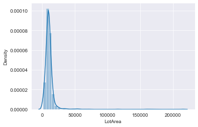

```python
sns.distplot(final_data.LotArea)
```

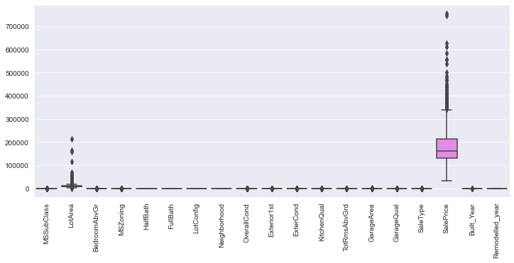

```python
sns.set_style('darkgrid')
plt.figure(figsize=(12, 5))
sns.boxplot(data=num, orient='v')
plt.xticks(rotation=90)
plt.show()
```

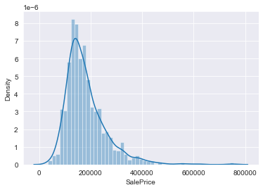

```python
#lot area and sale price have outliers
sns.distplot(final_data.SalePrice)
```

```python
#iqr method
num=final_data[['LotArea','SalePrice']]
for i in num:
    q1=np.percentile(num,25,interpolation='midpoint')
    q2=np.percentile(num,50,interpolation='midpoint')
    q3=np.percentile(num,75,interpolation='midpoint')
    iqr=q3-q1
    up_lim=q3+1.5*iqr
    low_lim=q1-1.*iqr
    ind1=data.select_dtypes(include=['float','integer'])[i]>up_lim
    ind2=data.select_dtypes(include=['float','integer'])[i]<low_lim
    #data.drop(data.loc[ind1].index,inplace=True)
    # data.drop(data.loc[ind2].index,inplace=True
```

```python
final_data[ind1]
```

|  | MSSubClass | LotArea | BedroomAbvGr | MSZoning | HalfBath | FullBath | LotConfig | Neighborhood | OverallCond | Exterior1st | ExterCond | KitchenQual | TotRmsAbvGrd | GarageArea | GarageQual | SaleType | SalePrice | Built_Year | Remodelled_year |
| --- | --- | --- | --- | --- | --- | --- | --- | --- | --- | --- | --- | --- | --- | --- | --- | --- | --- | --- | --- |
| 58 | 60 | 13682 | 3 | 3 | 1 | 3 | 1 | 22 | 5 | 12 | 4 | 2 | 10 | 641 | 4 | 6 | 438780 | 4 | 4 |
| 161 | 60 | 13688 | 3 | 3 | 1 | 2 | 4 | 16 | 5 | 12 | 4 | 0 | 10 | 726 | 4 | 8 | 412500 | 7 | 6 |
| 178 | 20 | 17423 | 1 | 3 | 0 | 2 | 1 | 22 | 5 | 12 | 4 | 0 | 9 | 1166 | 4 | 6 | 501837 | 2 | 1 |
| 185 | 75 | 22950 | 4 | 4 | 1 | 2 | 4 | 17 | 9 | 13 | 2 | 0 | 12 | 840 | 0 | 8 | 475000 | 118 | 17 |
| 231 | 60 | 15138 | 4 | 3 | 1 | 2 | 4 | 15 | 5 | 12 | 4 | 0 | 9 | 810 | 4 | 8 | 403000 | 15 | 14 |
| 278 | 20 | 14450 | 3 | 3 | 1 | 2 | 4 | 16 | 5 | 5 | 4 | 0 | 8 | 732 | 4 | 6 | 415298 | 4 | 3 |
| 349 | 60 | 20431 | 4 | 3 | 1 | 2 | 4 | 16 | 5 | 5 | 4 | 0 | 10 | 706 | 4 | 6 | 437154 | 5 | 4 |
| 378 | 20 | 11394 | 1 | 3 | 1 | 1 | 0 | 22 | 2 | 12 | 4 | 0 | 8 | 834 | 4 | 6 | 394432 | 0 | 0 |
| 389 | 60 | 12474 | 3 | 3 | 1 | 2 | 4 | 16 | 5 | 12 | 4 | 0 | 9 | 846 | 4 | 6 | 426000 | 3 | 2 |
| 440 | 20 | 15431 | 2 | 3 | 0 | 2 | 4 | 16 | 5 | 12 | 4 | 0 | 10 | 672 | 4 | 8 | 555000 | 2 | 2 |
| 473 | 20 | 14977 | 2 | 3 | 0 | 2 | 4 | 16 | 5 | 12 | 4 | 2 | 7 | 908 | 4 | 6 | 440000 | 4 | 3 |
| 496 | 20 | 12692 | 4 | 3 | 0 | 3 | 4 | 15 | 5 | 3 | 4 | 2 | 10 | 546 | 4 | 8 | 430000 | 18 | 17 |
| 515 | 20 | 12220 | 3 | 3 | 1 | 2 | 4 | 16 | 5 | 5 | 4 | 0 | 9 | 900 | 4 | 6 | 402861 | 1 | 1 |
| 527 | 60 | 14948 | 3 | 3 | 1 | 2 | 4 | 16 | 5 | 12 | 4 | 0 | 11 | 858 | 4 | 6 | 446261 | 2 | 2 |
| 591 | 60 | 13478 | 3 | 3 | 1 | 2 | 0 | 16 | 5 | 5 | 4 | 0 | 10 | 842 | 4 | 4 | 451950 | 2 | 2 |
| 661 | 60 | 46589 | 4 | 3 | 1 | 2 | 1 | 15 | 7 | 12 | 4 | 2 | 8 | 711 | 4 | 8 | 402000 | 16 | 5 |
| 664 | 20 | 20896 | 1 | 3 | 1 | 1 | 1 | 21 | 5 | 12 | 4 | 0 | 8 | 1134 | 4 | 6 | 423000 | 5 | 4 |
| 691 | 60 | 21535 | 4 | 3 | 1 | 3 | 0 | 15 | 6 | 6 | 4 | 0 | 10 | 832 | 4 | 8 | 755000 | 16 | 15 |
| 769 | 60 | 53504 | 4 | 3 | 1 | 3 | 1 | 22 | 5 | 5 | 4 | 0 | 12 | 841 | 4 | 8 | 538000 | 7 | 7 |
| 774 | 20 | 14226 | 3 | 3 | 0 | 2 | 0 | 16 | 5 | 12 | 4 | 2 | 9 | 895 | 4 | 6 | 395000 | 4 | 4 |
| 798 | 60 | 13518 | 4 | 3 | 1 | 3 | 4 | 16 | 5 | 12 | 4 | 0 | 11 | 820 | 4 | 6 | 485000 | 2 | 1 |
| 803 | 60 | 13891 | 4 | 3 | 1 | 3 | 4 | 16 | 5 | 12 | 4 | 0 | 12 | 1020 | 4 | 6 | 582933 | 2 | 1 |
| 898 | 20 | 12919 | 2 | 3 | 1 | 2 | 4 | 16 | 5 | 12 | 4 | 0 | 11 | 820 | 4 | 6 | 611657 | 1 | 0 |
| 987 | 20 | 10159 | 3 | 3 | 1 | 2 | 4 | 16 | 5 | 12 | 4 | 0 | 8 | 606 | 4 | 6 | 395192 | 1 | 0 |
| 1046 | 60 | 16056 | 4 | 3 | 1 | 3 | 4 | 22 | 5 | 5 | 4 | 0 | 11 | 716 | 4 | 6 | 556581 | 5 | 4 |
| 1142 | 60 | 9965 | 4 | 3 | 0 | 3 | 4 | 5 | 5 | 12 | 4 | 2 | 11 | 1052 | 4 | 6 | 424870 | 4 | 3 |
| 1169 | 60 | 35760 | 4 | 3 | 1 | 3 | 1 | 15 | 5 | 6 | 2 | 2 | 10 | 807 | 4 | 8 | 625000 | 15 | 14 |
| 1182 | 60 | 15623 | 4 | 3 | 1 | 3 | 0 | 15 | 5 | 13 | 4 | 0 | 10 | 813 | 4 | 8 | 745000 | 14 | 14 |
| 1243 | 20 | 13891 | 2 | 3 | 1 | 2 | 4 | 16 | 5 | 12 | 4 | 0 | 7 | 850 | 4 | 6 | 465000 | 4 | 4 |
| 1353 | 50 | 14720 | 4 | 3 | 1 | 2 | 1 | 15 | 5 | 12 | 4 | 2 | 9 | 666 | 4 | 8 | 410000 | 15 | 14 |
| 1373 | 20 | 11400 | 2 | 3 | 1 | 2 | 4 | 15 | 5 | 12 | 4 | 0 | 8 | 804 | 4 | 8 | 466500 | 9 | 8 |
| 1437 | 20 | 12444 | 2 | 3 | 0 | 2 | 2 | 16 | 5 | 12 | 4 | 0 | 7 | 774 | 4 | 6 | 394617 | 2 | 2 |

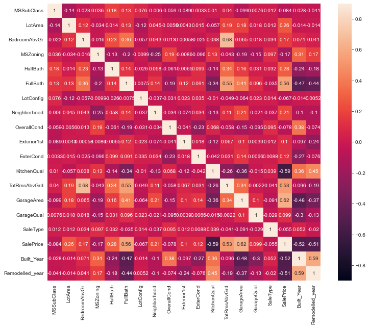

```python
plt.figure(figsize=(12,10))
sns.heatmap(final_data.corr(),vmin=-0.9,vmax=0.9,annot=True)
plt.show()
```

# standard scaler

```python
from sklearn.preprocessing import StandardScaler
scaler=StandardScaler()
final_data[['LotArea','GarageArea','SalePrice']]=scaler.fit_transform(final_data[['LotArea','GarageArea','SalePrice']])
```

```python
x=final_data.drop(['SalePrice'],axis=1)
y=final_data['SalePrice']
```

### Model Selection

```python
from sklearn.model_selection import train_test_split
x_train,x_test,y_train,y_test=train_test_split(x,y,test_size=0.2,random_state=42)
```

```python
from sklearn.linear_model import LinearRegression
from sklearn.metrics import r2_score,mean_squared_error
lr=LinearRegression()
lr.fit(x_train,y_train)
y_pred=lr.predict(x_test)
print('R2_score of the model {} ----  mean_squared_error {}'.format(r2_score(y_pred,y_test),mean_squared_error(y_pred,y_test)))
```

```
R2_score of the model 0.5176498334138278 ----  mean_squared_error 0.35412237883118564
```

```python
from sklearn.tree import DecisionTreeRegressor
tr=DecisionTreeRegressor()
tr.fit(x_train,y_train)
y_pred=tr.predict(x_test)
print('R2_score of the model {} ----  mean_squared_error {}'.format(r2_score(y_pred,y_test),mean_squared_error(y_pred,y_test)))
```

```
R2_score of the model 0.6762513508747588 ----  mean_squared_error 0.36631297843448846
```

```python
from sklearn.ensemble import RandomForestRegressor
rf=RandomForestRegressor()
rf.fit(x_train,y_train)
y_pred=rf.predict(x_test)
print('R2_score of the model {} ----  mean_squared_error {}'.format(r2_score(y_pred,y_test),mean_squared_error(y_pred,y_test)))
```

```
R2_score of the model 0.7627120540532016 ----  mean_squared_error 0.2012112898011173
```

```python
from sklearn.ensemble import GradientBoostingRegressor
gr=GradientBoostingRegressor()
gr.fit(x_train,y_train)
y_pred=gr.predict(x_test)
print('R2_score of the model {} ----  mean_squared_error {}'.format(r2_score(y_pred,y_test),mean_squared_error(y_pred,y_test)))
```

```
R2_score of the model 0.7355270269738717 ----  mean_squared_error 0.21963979352611493
```

### Hyperparameter Tuning

```python
'''from sklearn.model_selection import KFold,cross_val_score
kfold = KFold(n_splits=5, shuffle=True, random_state=42)
result=cross_val_score(rf,x,y,cv=kfold)
np.mean(result)'''
```

```
'from sklearn.model_selection import KFold,cross_val_score\nkfold = KFold(n_splits=5, shuffle=True, random_state=42)\nresult=cross_val_score(rf,x,y,cv=kfold)\nnp.mean(result)'
```

```python
from sklearn.model_selection import KFold,cross_val_score
kfold = KFold(n_splits=10, shuffle=True, random_state=42)
result=cross_val_score(gr,x,y,cv=kfold)
np.mean(result)
```

```
0.788664213931397
```

```python
from sklearn.model_selection import GridSearchCV
param={'n_estimators':[10,150,300],
       'max_depth':[30,60,90,None],
       'max_features': ['log2', 'sqrt']
    }
gv=GridSearchCV(estimator=gr,param_grid=param,scoring='accuracy',cv=10,n_jobs=-1)
gv.fit(x_train,y_train)
# Extract best hyperparameters from 'grid_dt'
best_hyperparams = gv.best_params_
print('Best hyerparameters:\n', best_hyperparams)

# Extract best CV score from 'grid_dt'
#best_CV_score = grid_rf.best_score_
#print(best_CV_score)

# Extract best model from 'grid_dt'
best_model = gv.best_estimator_
y_pred=best_model.predict(x_test)
print('R2_score of the model {} ----  mean_squared_error {}'.format(r2_score(y_pred,y_test),mean_squared_error(y_pred,y_test)))
```

```
Best hyerparameters:
 {'max_depth': 30, 'max_features': 'log2', 'n_estimators': 10}
R2_score of the model -0.05981586441909337 ----  mean_squared_error 0.36975050366585527
```

```python
params_rf = {'n_estimators': [400, 800, 1000],
             'max_depth': [8, 16, 32],
             'max_features': ['log2', 'sqrt']}
grid_rf = GridSearchCV(estimator=gr,
                       param_grid=params_rf,
                       cv=10,
                       scoring='accuracy',
                        n_jobs=-1)
grid_rf.fit(x_train, y_train)
# Extract best hyperparameters from 'grid_dt'
best_hyperparams = grid_rf.best_params_
print('Best hyerparameters:\n', best_hyperparams)

# Extract best CV score from 'grid_dt'
#best_CV_score = grid_rf.best_score_
#print(best_CV_score)

# Extract best model from 'grid_dt'
best_model = grid_rf.best_estimator_
y_pred=best_model.predict(x_test)
print('R2_score of the model {} ----  mean_squared_error {}'.format(r2_score(y_pred,y_test),mean_squared_error(y_pred,y_test)))
```

```
Best hyerparameters:
 {'max_depth': 8, 'max_features': 'log2', 'n_estimators': 400}
R2_score of the model 0.7690281264717846 ----  mean_squared_error 0.200881910241568
```

```python
from sklearn.ensemble import GradientBoostingRegressor
gr=GradientBoostingRegressor(max_depth=8,max_features='log2',n_estimators=400)
gr.fit(x_train,y_train)
y_pred=gr.predict(x_test)
print('R2_score of the model {} ----  mean_squared_error {}'.format(r2_score(y_pred,y_test),mean_squared_error(y_pred,y_test)))
```

```
R2_score of the model 0.7884291822747073 ----  mean_squared_error 0.19477453720609833
```

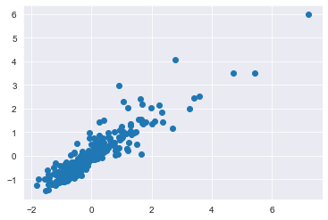

```python
plt.scatter(y_test,y_pred)
plt.show()
```

### feature importance

```python
feature_importances = pd.DataFrame(gr.feature_importances_, index =x.columns,  columns=['valuable']).sort_values('valuable', ascending=False)*100
feature_importances.nlargest(15,'valuable')
```

|  | valuable |
| --- | --- |
| GarageArea | 18.213478 |
| FullBath | 13.227646 |
| Built_Year | 12.609210 |
| LotArea | 10.028719 |
| KitchenQual | 9.878439 |
| Remodelled_year | 8.878763 |
| Neighborhood | 6.985559 |
| TotRmsAbvGrd | 6.701056 |
| HalfBath | 2.630617 |
| MSSubClass | 2.412302 |
| BedroomAbvGr | 2.079106 |
| Exterior1st | 1.536834 |
| OverallCond | 1.473690 |
| MSZoning | 1.140255 |
| LotConfig | 0.837292 |

```python
feature_importances.nlargest(10,'valuable').T.columns
```

```
Index(['GarageArea', 'FullBath', 'Built_Year', 'LotArea', 'KitchenQual',
       'Remodelled_year', 'Neighborhood', 'TotRmsAbvGrd', 'HalfBath',
       'MSSubClass'],
      dtype='object')
```

```python
data2=final_data[['GarageArea', 'KitchenQual', 'LotArea', 'Built_Year', 'TotRmsAbvGrd',
       'Remodelled_year', 'Neighborhood', 'FullBath', 'Exterior1st',
       'MSSubClass','SalePrice']]
```

```python
data2.describe().T
```

|  | count | mean | std | min | 25% | 50% | 75% | max |
| --- | --- | --- | --- | --- | --- | --- | --- | --- |
| GarageArea | 1460.0 | -2.022735e-17 | 1.000343 | -2.212963 | -0.647916 | 0.032844 | 0.482006 | 4.421526 |
| KitchenQual | 1460.0 | 2.339726e+00 | 0.830161 | 0.000000 | 2.000000 | 3.000000 | 3.000000 | 3.000000 |
| LotArea | 1460.0 | -4.202783e-17 | 1.000343 | -0.923729 | -0.296991 | -0.104063 | 0.108708 | 20.518273 |
| Built_Year | 1460.0 | 3.873219e+01 | 30.202904 | 0.000000 | 10.000000 | 37.000000 | 56.000000 | 138.000000 |
| TotRmsAbvGrd | 1460.0 | 6.517808e+00 | 1.625393 | 2.000000 | 5.000000 | 6.000000 | 7.000000 | 14.000000 |
| Remodelled_year | 1460.0 | 2.513425e+01 | 20.645407 | 0.000000 | 6.000000 | 16.000000 | 43.000000 | 60.000000 |
| Neighborhood | 1460.0 | 1.225137e+01 | 6.013735 | 0.000000 | 7.000000 | 12.000000 | 17.000000 | 24.000000 |
| FullBath | 1460.0 | 1.565068e+00 | 0.550916 | 0.000000 | 1.000000 | 2.000000 | 2.000000 | 3.000000 |
| Exterior1st | 1460.0 | 9.624658e+00 | 3.197659 | 0.000000 | 8.000000 | 12.000000 | 12.000000 | 14.000000 |
| MSSubClass | 1460.0 | 5.689726e+01 | 42.300571 | 20.000000 | 20.000000 | 50.000000 | 70.000000 | 190.000000 |
| SalePrice | 1460.0 | 1.180182e-16 | 1.000343 | -1.838704 | -0.641516 | -0.225664 | 0.416529 | 7.228819 |

```python
x=data2.drop(['SalePrice'],axis=1)
y=data2['SalePrice']
```

```python
x_train,x_test,y_train,y_test=train_test_split(x,y,test_size=0.2,random_state=42)
```

```python
gr=GradientBoostingRegressor()
gr.fit(x_train,y_train)
y_pred=gr.predict(x_test)
print('R2_score of the model {} ----  mean_squared_error {}'.format(r2_score(y_pred,y_test),mean_squared_error(y_pred,y_test)))
```

```
R2_score of the model 0.7335074370090797 ----  mean_squared_error 0.22090313850885984
```

```python
from sklearn.model_selection import KFold,cross_val_score
kfold = KFold(n_splits=10, shuffle=True, random_state=42)
result=cross_val_score(gr,x,y,cv=kfold)
np.mean(result)
```

```
0.7853107531101804
```

```python
params_rf = {'n_estimators': [400, 800, 1000],
             'max_depth': [8, 16, 32],
             'max_features': ['log2', 'sqrt']}
grid_rf = GridSearchCV(estimator=gr,
                       param_grid=params_rf,
                       cv=5,
                       scoring='accuracy',
                        n_jobs=-1)
grid_rf.fit(x_train, y_train)
# Extract best hyperparameters from 'grid_dt'
best_hyperparams = grid_rf.best_params_
print('Best hyerparameters:\n', best_hyperparams)

# Extract best CV score from 'grid_dt'
#best_CV_score = grid_rf.best_score_
#print(best_CV_score)

# Extract best model from 'grid_dt'
best_model = grid_rf.best_estimator_
y_pred=best_model.predict(x_test)
print('R2_score of the model {} ----  mean_squared_error {}'.format(r2_score(y_pred,y_test),mean_squared_error(y_pred,y_test)))
```

```
Best hyerparameters:
 {'max_depth': 8, 'max_features': 'log2', 'n_estimators': 400}
R2_score of the model 0.7769144080015612 ----  mean_squared_error 0.19833961103094921
```

```python
gr=GradientBoostingRegressor(max_depth=8,max_features='log2',n_estimators=400)
gr.fit(x_train,y_train)
y_pred=gr.predict(x_test)
print('R2_score of the model {} ----  mean_squared_error {}'.format(r2_score(y_pred,y_test),mean_squared_error(y_pred,y_test)))
```

```
R2_score of the model 0.7783637920819098 ----  mean_squared_error 0.2012132105703187
```

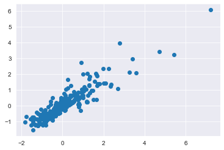

```python
plt.scatter(y_test,y_pred)
plt.show()
```

```python
import pickle
pickle.dump(gr,open('model.pkl','wb'))
```